# DATS 6101 Homework 5

Chris Montgomery

2/18/2019

# Question 2

```r
#Read in our data
bikeorig <- read.csv("bikedata.csv")
bikeorig$Date <- as.Date(bikeorig$Date, format = "%m/%d/%Y")

#Remove variables we are not interested in
bike <- bikeorig %>% select (everything(), -c(Casual.Users, Registered.Users, Date )) %>% rename(Weekday = Day.of.the.Week, Temp.Feel = Temperature.Feels.F, Temp.F = Temperature.F )
str(bike)
```

```
## 'data.frame':    17379 obs. of  11 variables:
##  $ Season      : int  4 4 4 4 4 4 4 4 4 4 ...
##  $ Hour        : int  0 1 2 3 4 5 6 7 8 9 ...
##  $ Holiday     : int  0 0 0 0 0 0 0 0 0 0 ...
##  $ Weekday     : int  6 6 6 6 6 6 6 6 6 6 ...
##  $ Working.Day : int  0 0 0 0 0 0 0 0 0 0 ...
##  $ Weather.Type: int  1 1 1 1 1 2 1 1 1 1 ...
##  $ Temp.F      : num  36.6 34.9 34.9 36.6 36.6 36.6 34.9 33.1 36.6 43.5 ...
##  $ Temp.Feel   : num  37.4 35.6 35.6 37.4 37.4 33.8 35.6 33.8 37.4 44.6 ...
##  $ Humidity    : int  81 80 80 75 75 75 80 86 75 76 ...
##  $ Wind.Speed  : int  0 0 0 0 0 6 0 0 0 0 ...
##  $ Total.Users : int  16 40 32 13 1 1 2 3 8 14 ...
```

Bike has a total of 11 variables. 9 are registered as integers, while 2 are numeric.

# Question 3

```r
#Filter observations by hour range
nrow (bike %>% filter (Hour > 13, Hour < 19))
```

```
## [1] 3646
```

There are 3,646 observations during the afternoon rush hour.

# Question 4

```r
#Craate a correlation matrix for our variables of interest. Plot matrix

correlation.matrix <- cor(bike); round(correlation.matrix, 2)
```

```
##              Season  Hour Holiday Weekday Working.Day Weather.Type Temp.F
## Season         1.00  0.00    0.06    0.00       -0.04         0.04  -0.47
## Hour           0.00  1.00    0.00    0.00        0.00        -0.02   0.14
## Holiday        0.06  0.00    1.00   -0.10       -0.25        -0.02  -0.03
## Weekday        0.00  0.00   -0.10    1.00        0.04         0.00   0.00
## Working.Day   -0.04  0.00   -0.25    0.04        1.00         0.04   0.06
## Weather.Type   0.04 -0.02   -0.02    0.00        0.04         1.00  -0.10
## Temp.F        -0.47  0.14   -0.03    0.00        0.06        -0.10   1.00
## Temp.Feel     -0.47  0.13   -0.03   -0.01        0.05        -0.11   0.99
## Humidity       0.01 -0.28   -0.01   -0.04        0.02         0.42  -0.07
## Wind.Speed    -0.04  0.14    0.00    0.01       -0.01         0.03  -0.02
## Total.Users   -0.14  0.39   -0.03    0.03        0.03        -0.14   0.40
##              Temp.Feel Humidity Wind.Speed Total.Users
## Season           -0.47     0.01      -0.04       -0.14
## Hour              0.13    -0.28       0.14        0.39
## Holiday          -0.03    -0.01       0.00       -0.03
## Weekday          -0.01    -0.04       0.01        0.03
## Working.Day       0.05     0.02      -0.01        0.03
## Weather.Type     -0.11     0.42       0.03       -0.14
## Temp.F            0.99    -0.07      -0.02        0.40
## Temp.Feel         1.00    -0.05      -0.06        0.40
## Humidity         -0.05     1.00      -0.29       -0.32
## Wind.Speed       -0.06    -0.29       1.00        0.09
## Total.Users       0.40    -0.32       0.09        1.00
```

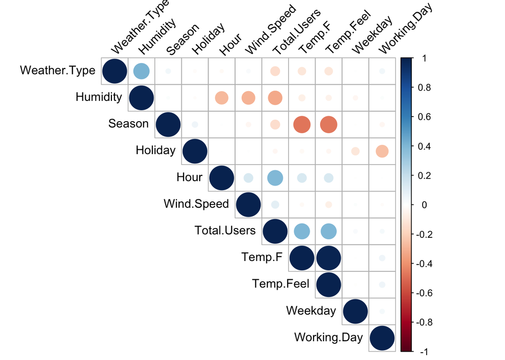

```r
library(corrplot)
corrplot(correlation.matrix, type = "upper", order = "hclust",
         tl.col = "black", tl.srt = 45)
```

# Question 5

```r
#Convert categorical variables to factor
factor.variables <- c("Season", "Holiday", "Weekday", "Working.Day", "Weather.Type")
bike[factor.variables] <- lapply(bike[factor.variables], factor)
```

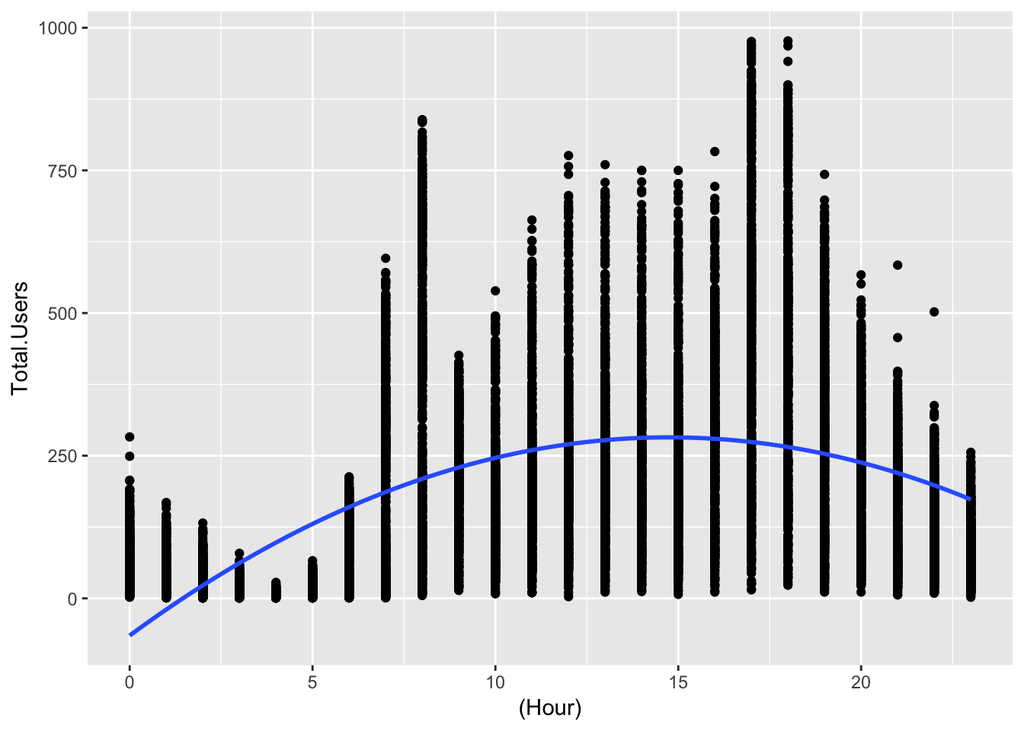

```r
#Create a plot to visualize relationship between users and hour of day
ggplot(bike, aes(x = (Hour), y = Total.Users)) + geom_point() +
  geom_smooth(se = FALSE, method = "gam", formula = y ~ (x + I(x^2)))
```

Based on the above plot, we need to rethink how the “Hour” variable is treated. I think there are two potentially appropriate measures we can take. First, we can keep it ordinal, but change the start and end points (I.E. Hour begins with 0 at 5 AM). Otherwise, we can convert the hour variable to categorical. For now we can try both and see which improves the model fit the most. However, it’s likely that treating the variable as categorical will result in a better fit simply by add 24 new dummy variables in the regression. This could raise concerns about overfitting. However, our sample size is pretty large.

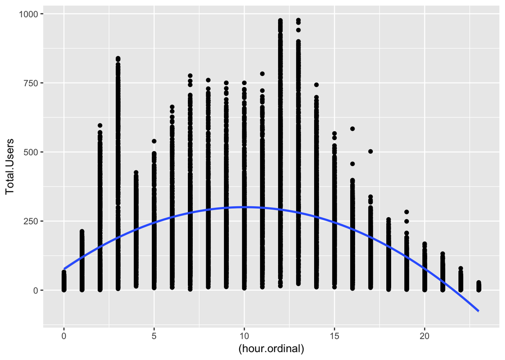

```r
#Create a new variable that represents hour of day treated as a continuous variable
bike$hour.ordinal <- bike$Hour - 5
bike[bike$hour.ordinal < 0, ]$hour.ordinal <-24  + bike[bike$hour.ordinal < 0, ]$hour.ordinal

ggplot(bike, aes(x = (hour.ordinal), y = Total.Users)) + geom_point() +
  stat_smooth(method = "lm", formula = y ~ x + I(x^2), size = 1)
```

```r
#Create an hour variable that is categorical
bike$hour.categorical <- as.factor(bike$Hour)
```

# Question 6

```r
#Fit a linear model, check VIF
lm1 <- lm(Total.Users ~ Weekday  + Temp.Feel + Hour + Humidity + Weather.Type, data = bike); summary(lm1)
```

```
##
## Call:
## lm(formula = Total.Users ~ Weekday + Temp.Feel + Hour + Humidity +
##     Weather.Type, data = bike)
##
## Residuals:
##     Min      1Q  Median      3Q     Max
## -340.12  -95.44  -30.51   53.72  721.35
##
## Coefficients:
##                Estimate Std. Error t value Pr(>|t|)
## (Intercept)    36.77934    6.49563   5.662 1.52e-08 ***
## Weekday1        3.10371    4.21573   0.736  0.46161
## Weekday2        7.60944    4.23068   1.799  0.07209 .
## Weekday3       11.58251    4.22173   2.744  0.00608 **
## Weekday4        7.61434    4.22081   1.804  0.07125 .
## Weekday5       13.20646    4.21177   3.136  0.00172 **
## Weekday6       12.48559    4.19967   2.973  0.00295 **
## Temp.Feel       3.11578    0.05615  55.487  < 2e-16 ***
## Hour            7.56505    0.17251  43.853  < 2e-16 ***
## Humidity       -2.07909    0.06748 -30.809  < 2e-16 ***
## Weather.Type2  13.80559    2.74275   5.033 4.86e-07 ***
## Weather.Type3 -23.30715    4.54883  -5.124 3.03e-07 ***
## Weather.Type4  44.75004   85.86713   0.521  0.60227
## ---
## Signif. codes:  0 '***' 0.001 '**' 0.01 '*' 0.05 '.' 0.1 ' ' 1
##
## Residual standard error: 148.6 on 17366 degrees of freedom
## Multiple R-squared:  0.3293, Adjusted R-squared:  0.3288
## F-statistic: 710.5 on 12 and 17366 DF,  p-value: < 2.2e-16
```

```r
vif (lm1)
```

```
##      Weekday1      Weekday2      Weekday3      Weekday4      Weekday5
##      1.710510      1.707578      1.713080      1.710022      1.711892
##      Weekday6     Temp.Feel          Hour      Humidity Weather.Type2
##      1.716291      1.034200      1.119620      1.333929      1.143207
## Weather.Type3 Weather.Type4
##      1.221050      1.001482
```

```r
#Lets create a variable that captures holidays and weekends together. Could give us a few more degrees of freedom lost with using hour * Holiday and hour * working.day interactions

bike$day.off <- ifelse(bike$Working.Day == 0 | bike$Holiday == 1,1,0)
```

# Q7-9

The below code produces 8 different linear model specifications. For brevity, I will discuss the modeling decisions and findings regarding my preferred specification lm9. In this model, I included continuous variables capturing the termperature feel, windspeed, and humidity. Each value was statistically significant at above the 95% confidence level. I intentionally chose not to included a real temperature variable due to concerns over multicollinearity with the perceived temperature variable. In addition to the continuous variables, I included categorical variables representing the hour of day, season, weather type, and a dummy capturing whether a non-working day (holiday + weekend). Finally, I included an interaction terms between the day off dummy and hour of day variable as well as temperature feel and season. In creating the first interaction, I attempted to capture the different motivations for biking during certain times of the day, namely the different affects of the daily commute vs. leasure riding. The second interaction term attempts to capture an assumed positive correlation between temperature and total users during cold months, and a negative correlation during hot months. Point estimates for each variable can be viewed in the summary table below.

Model 9, the preferred regression specification yielded an adjusted R^2 value of .76. VIF values looking generally appropriate, with the exception of variables featured in the interaction terms. This is to be expected, and should not be a cause for concern. However, some concerns do remain. First, the inclusion of hour of day categorical variables increases concerns over model overfitting. Each use of the categorical variable creates 24 separate dummy variables. In so doing, it’s possible the R^2 of the model is being artificially increased. However, I argue that I have a sound theoretical justification for its inclusion.

In addition, an ACF plot of the residuals show significant levels of autocorrelation within the residuals. This suggests the model could be misspecified with innacurate standard errors. Introducing some mechanism to account for time could help deal with the autocorrelation issues.

```r
lm9 <- lm(Total.Users~  Temp.Feel + hour.categorical + Wind.Speed + Humidity + Season + Weather.Type + Temp.Feel * Season + day.off +  (day.off * hour.categorical), data = bike)

lm2 <- lm(Total.Users~ Weekday  + Temp.Feel + I(Temp.Feel^2) + Hour+ I(Hour^2) + Humidity + I(Humidity^2)+ Wind.Speed + Season + Weather.Type + Temp.Feel * Season, data = bike)


lm3 <- lm(Total.Users~ Weekday  + Holiday+ Temp.Feel + I(Temp.Feel^2) + Hour+ I(Hour^2) + Humidity + I(Humidity^2)+ Wind.Speed + Season + Weather.Type + Temp.Feel * Season, data = bike)

lm4 <- lm(Total.Users~ Weekday  + Holiday+ Temp.Feel + Hour+ I(Hour^2)  + I(Humidity^2)+ Wind.Speed + Season + Weather.Type + Temp.Feel * Season, data = bike)

lm5 <- lm(Total.Users~ Weekday  + Holiday+ Temp.Feel + hour.ordinal+ I(hour.ordinal^2)  + I(Humidity^2)+ Wind.Speed + Season + Weather.Type + Temp.Feel * Season, data = bike)

lm6 <- lm(Total.Users~ Weekday  + Holiday+ Temp.Feel + hour.categorical  + I(Humidity^2)+ Wind.Speed + Season + Weather.Type + Temp.Feel * Season, data = bike)


lm7 <- lm(Total.Users~ Weekday  + Holiday+ Temp.Feel + hour.categorical + hour.categorical * Holiday  + I(Humidity^2)+ Wind.Speed + Season + Weather.Type + Temp.Feel * Season, data = bike)

lm8 <- lm(Total.Users~ Weekday  + Holiday+ Temp.Feel + hour.categorical + hour.categorical * Holiday  + I(Humidity^2)+ Wind.Speed + Season + Weather.Type + Temp.Feel * Season + hour.categorical * Working.Day, data = bike)


summary(lm9)
```

```
##
## Call:
## lm(formula = Total.Users ~ Temp.Feel + hour.categorical + Wind.Speed +
##     Humidity + Season + Weather.Type + Temp.Feel * Season + day.off +
##     (day.off * hour.categorical), data = bike)
##
## Residuals:
##     Min      1Q  Median      3Q     Max
## -443.17  -50.45   -5.24   46.25  464.40
##
## Coefficients:
##                              Estimate Std. Error t value Pr(>|t|)
## (Intercept)                 -68.88849    7.42337  -9.280  < 2e-16 ***
## Temp.Feel                     3.48548    0.09140  38.134  < 2e-16 ***
## hour.categorical1           -16.35323    5.66517  -2.887 0.003899 **
## hour.categorical2           -21.98080    5.68719  -3.865 0.000112 ***
## hour.categorical3           -25.20473    5.74128  -4.390 1.14e-05 ***
## hour.categorical4           -21.88393    5.74469  -3.809 0.000140 ***
## hour.categorical5             1.65106    5.67119   0.291 0.770954
## hour.categorical6            81.18054    5.66825  14.322  < 2e-16 ***
## hour.categorical7           267.87795    5.66363  47.298  < 2e-16 ***
## hour.categorical8           447.46558    5.66222  79.027  < 2e-16 ***
## hour.categorical9           203.05108    5.67023  35.810  < 2e-16 ***
## hour.categorical10           86.86340    5.68374  15.283  < 2e-16 ***
## hour.categorical11           97.92507    5.71137  17.146  < 2e-16 ***
## hour.categorical12          133.09567    5.73803  23.195  < 2e-16 ***
## hour.categorical13          124.51289    5.75943  21.619  < 2e-16 ***
## hour.categorical14          105.34542    5.77743  18.234  < 2e-16 ***
## hour.categorical15          121.07590    5.78328  20.936  < 2e-16 ***
## hour.categorical16          215.24783    5.77151  37.295  < 2e-16 ***
## hour.categorical17          452.31743    5.75097  78.651  < 2e-16 ***
## hour.categorical18          424.07557    5.73317  73.969  < 2e-16 ***
## hour.categorical19          285.24244    5.70138  50.030  < 2e-16 ***
## hour.categorical20          193.54740    5.68016  34.074  < 2e-16 ***
## hour.categorical21          135.21448    5.66491  23.869  < 2e-16 ***
## hour.categorical22           93.03935    5.65777  16.445  < 2e-16 ***
## hour.categorical23           48.06786    5.65444   8.501  < 2e-16 ***
## Wind.Speed                   -0.70457    0.08911  -7.906 2.81e-15 ***
## Humidity                     -1.16331    0.04779 -24.344  < 2e-16 ***
## Season2                     223.75117   12.60301  17.754  < 2e-16 ***
```

[output cut: 23 more lines]

```
## hour.categorical15:day.off  107.41016   10.04377  10.694  < 2e-16 ***
## hour.categorical16:day.off    7.25846   10.04199   0.723 0.469806
## hour.categorical17:day.off -253.56890   10.04139 -25.252  < 2e-16 ***
## hour.categorical18:day.off -262.89409   10.05104 -26.156  < 2e-16 ***
## hour.categorical19:day.off -164.46100   10.05159 -16.362  < 2e-16 ***
## hour.categorical20:day.off -123.47419   10.05132 -12.284  < 2e-16 ***
## hour.categorical21:day.off  -92.75849   10.05089  -9.229  < 2e-16 ***
## hour.categorical22:day.off  -72.93710   10.05083  -7.257 4.13e-13 ***
## hour.categorical23:day.off  -52.31580   10.05115  -5.205 1.96e-07 ***
## ---
## Signif. codes:  0 '***' 0.001 '**' 0.01 '*' 0.05 '.' 0.1 ' ' 1
##
## Residual standard error: 89.11 on 17319 degrees of freedom
## Multiple R-squared:  0.7595, Adjusted R-squared:  0.7587
## F-statistic:   927 on 59 and 17319 DF,  p-value: < 2.2e-16
```

```r
vif(lm9)
```

```
##                  Temp.Feel          hour.categorical1
##                   7.620473                   2.804558
##          hour.categorical2          hour.categorical3
##                   2.792771                   2.777500
##          hour.categorical4          hour.categorical5
##                   2.780797                   2.784516
##          hour.categorical6          hour.categorical7
##                   2.811311                   2.814138
##          hour.categorical8          hour.categorical9
##                   2.812735                   2.820707
##         hour.categorical10         hour.categorical11
##                   2.834163                   2.861786
##         hour.categorical12         hour.categorical13
##                   2.892358                   2.917799
##         hour.categorical14         hour.categorical15
##                   2.936072                   2.942014
##         hour.categorical16         hour.categorical17
##                   2.933898                   2.913052
##         hour.categorical18         hour.categorical19
##                   2.887462                   2.855530
##         hour.categorical20         hour.categorical21
##                   2.834314                   2.819115
##         hour.categorical22         hour.categorical23
##                   2.812011                   2.808702
##                 Wind.Speed                   Humidity
##                   1.167789                   1.860230
##                    Season2                    Season3
##                  65.764724                  25.948646
##                    Season4              Weather.Type2
##                  20.288401                   1.194469
##              Weather.Type3              Weather.Type4
##                   1.313991                   1.005612
##                    day.off          Temp.Feel:Season2
##                  23.970817                  76.228124
##          Temp.Feel:Season3          Temp.Feel:Season4
##                  26.512681                  13.744070
##  hour.categorical1:day.off  hour.categorical2:day.off
##                   2.892770                   2.881344
##  hour.categorical3:day.off  hour.categorical4:day.off
##                   2.889816                   2.889770
##  hour.categorical5:day.off  hour.categorical6:day.off
##                   2.824998                   2.880829
##  hour.categorical7:day.off  hour.categorical8:day.off
##                   2.897375                   2.897843
##  hour.categorical9:day.off hour.categorical10:day.off
##                   2.898447                   2.897477
## hour.categorical11:day.off hour.categorical12:day.off
##                   2.898093                   2.897013
## hour.categorical13:day.off hour.categorical14:day.off
##                   2.896358                   2.896224
## hour.categorical15:day.off hour.categorical16:day.off
##                   2.895839                   2.894812
## hour.categorical17:day.off hour.categorical18:day.off
##                   2.894467                   2.887642
## hour.categorical19:day.off hour.categorical20:day.off
##                   2.887958                   2.887803
## hour.categorical21:day.off hour.categorical22:day.off
##                   2.887557                   2.887522
## hour.categorical23:day.off
##                   2.887706
```

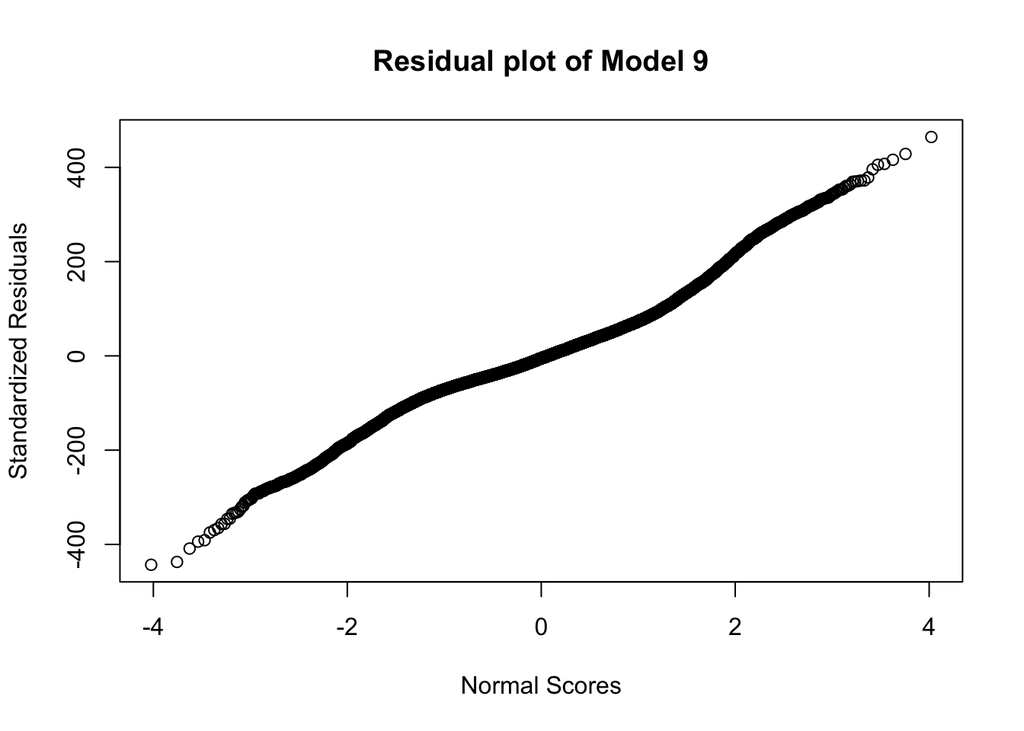

```r
 qqnorm(lm9$residuals,
     ylab="Standardized Residuals",
     xlab="Normal Scores",
    main="Residual plot of Model 9")
```

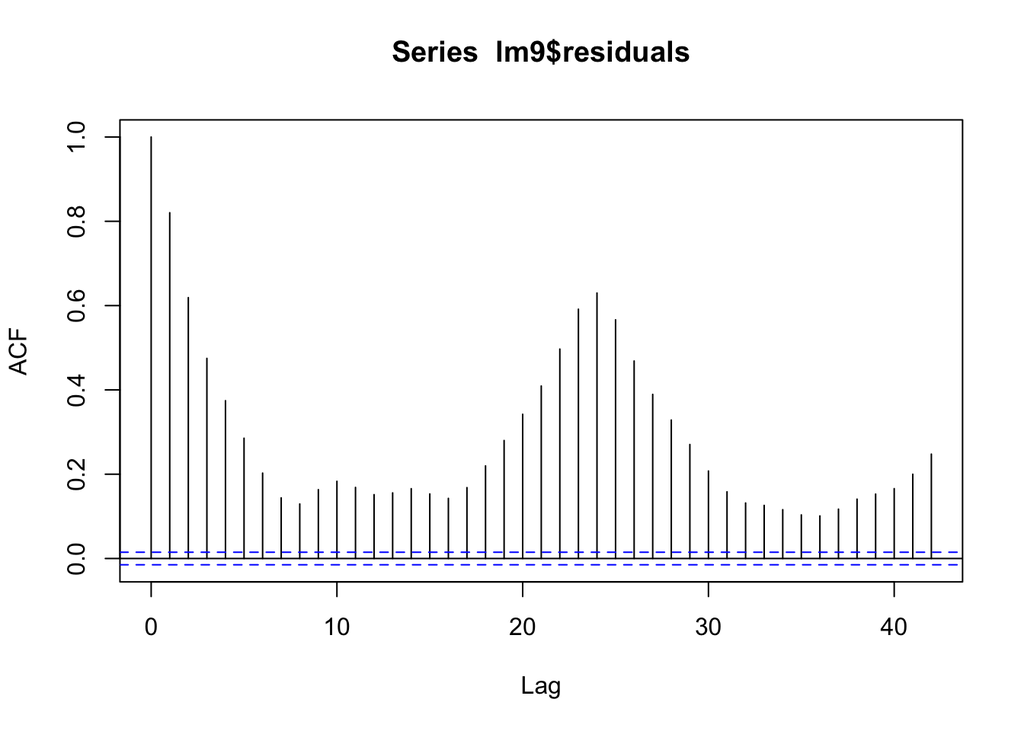

```r
acf(lm9$residuals)
```